# Sales Pipeline Analysis

## Sample Sales Funnel Analysis at Groundworks

This analysis is a sample of the insights and strategic recommendations I offer to the marketing management team at Groundworks.

**Glossary:**

- **Lead**: An individual who has expressed interest in Groundworks' services.
- **Qualified Lead**: A lead that has been evaluated and identified as having a high likelihood of converting into a paying customer.
- **Booked Appointment**: A lead who has scheduled an appointment for services or inspections with the Groundworks team.
- **Sales Funnel**: A model that outlines the key stages a customer goes through from initial interest in Groundworks' services to completing a purchase.
- **Sales Funnel Analysis**: The process of collecting and analyzing data from the sales funnel to map the customer journey.

### Step 1: Import libraries, and read in dataset

```python
import numpy as np
import pandas as pd
import seaborn as sns
import matplotlib.pyplot as plt
from sklearn import metrics
from sklearn.preprocessing import LabelEncoder
from sklearn.preprocessing import StandardScaler,normalize
from sklearn.decomposition import PCA, IncrementalPCA
from yellowbrick.cluster import KElbowVisualizer
from sklearn.cluster import KMeans, MiniBatchKMeans, AgglomerativeClustering
from sklearn.impute import SimpleImputer
from mpl_toolkits.mplot3d import Axes3D
from matplotlib.colors import ListedColormap
import warnings
import sys
```

```python
#Read dataset and display 2 records
df = pd.read_csv("sales_data.csv")
df.head(2).style.background_gradient('PuBu')
```

|  | LeadDate | LeadId | BranchName | BrandName | IsQualified | IsQuoted | Disposition | AppointmentSetDateTime | AppointmentType | AppointmentCancelReason | AppointmentCancelledDateTime | AppointmentStartTime | IsSold | SoldDate | SoldSubtotal | zip | DeadLeadReason |
| --- | --- | --- | --- | --- | --- | --- | --- | --- | --- | --- | --- | --- | --- | --- | --- | --- | --- |
| 0 | 7/23/2024 | 4826186 | Tulsa | Groundworks | 1 | 0 | nan | nan | nan | nan | nan | nan | 0 | nan | 0.000000 | 74055.000000 | nan |
| 1 | 7/23/2024 | 4826065 | Tulsa | Groundworks | 0 | 0 | nan | nan | nan | nan | nan | nan | 0 | nan | 0.000000 | 74114.000000 | Not the type of work we do |

### Step 2: Explore, clean and analyze dataset

```python
# This dataset has 162943 unique leads
leads = df['LeadId'].nunique()
print(f"There are {leads} unique leads in our dataset" )
```

```
There are 162943 unique leads in our dataset
```

```python
print(f" This dataset has the following shape: {df.shape}. This shows 162,943 records and 17 features.")
```

```
 This dataset has the following shape: (162943, 17). This shows 162,943 records and 17 features.
```

```python
print(f"The dataset has the following features: {list(df.columns)}")
```

[output not shown]

#### Qualified flag:

**IsQualified** is a flag for qualified leads. It is a 1, if the lead is qualified. The statistics below show that 79% of all leads in the imported table are qualifed. If this sample dataset is a good representation of Groundworks data, then we infer that 79% of the identified leads are qualified.

```python
df.describe().T.style.background_gradient('PuBu')
```

|  | count | mean | std | min | 25% | 50% | 75% | max |
| --- | --- | --- | --- | --- | --- | --- | --- | --- |
| LeadId | 162943.000000 | 4794658.564473 | 91333.365384 | 4646416.000000 | 4687621.500000 | 4804658.000000 | 4887813.500000 | 4928658.000000 |
| IsQualified | 162943.000000 | 0.790141 | 0.407209 | 0.000000 | 1.000000 | 1.000000 | 1.000000 | 1.000000 |
| IsQuoted | 162943.000000 | 0.363053 | 0.480882 | 0.000000 | 0.000000 | 0.000000 | 1.000000 | 1.000000 |
| IsSold | 162943.000000 | 0.105914 | 0.307729 | 0.000000 | 0.000000 | 0.000000 | 0.000000 | 1.000000 |
| SoldSubtotal | 162943.000000 | 1401.507289 | 6738.133296 | 0.000000 | 0.000000 | 0.000000 | 0.000000 | 622500.000000 |
| zip | 157944.000000 | 44884.082770 | 21304.122072 | 1301.000000 | 28658.000000 | 43607.000000 | 58301.000000 | 99352.000000 |

#### Missing values:

```python
df.info()
```

```
<class 'pandas.core.frame.DataFrame'>
RangeIndex: 162943 entries, 0 to 162942
Data columns (total 17 columns):
 #   Column                        Non-Null Count   Dtype
---  ------                        --------------   -----
 0   LeadDate                      162943 non-null  object
 1   LeadId                        162943 non-null  int64
 2   BranchName                    162943 non-null  object
 3   BrandName                     162943 non-null  object
 4   IsQualified                   162943 non-null  int64
 5   IsQuoted                      162943 non-null  int64
 6   Disposition                   68683 non-null   object
 7   AppointmentSetDateTime        96852 non-null   object
 8   AppointmentType               100417 non-null  object
 9   AppointmentCancelReason       16131 non-null   object
 10  AppointmentCancelledDateTime  16136 non-null   object
 11  AppointmentStartTime          96844 non-null   object
 12  IsSold                        162943 non-null  int64
 13  SoldDate                      17259 non-null   object
 14  SoldSubtotal                  162943 non-null  float64
 15  zip                           157944 non-null  float64
 16  DeadLeadReason                61360 non-null   object
dtypes: float64(2), int64(4), object(11)
memory usage: 21.1+ MB
```

#### Quick view: gross leads, qualifed leads and booked appointments by branch and month

With the view below, managers can analyze branch size and performance in relation to lead generation.

```python
# Convert 'LeadDate' to datetime, handling errors by coercing them to NaT
df['LeadDate'] = pd.to_datetime(df['LeadDate'], errors='coerce')

# Extract month as the month name
df['Month'] = df['LeadDate'].dt.strftime('%B')

# Remove invalid branches
branches_to_remove = ["Call Center Huntsville", "Call Center VB", "Canyon Lake"]
df = df[~df['BranchName'].isin(branches_to_remove)].copy()

# Add appointment count
df['appointment_count'] = df['AppointmentSetDateTime'].notnull().astype(int)

# Group by Month and BranchName
monthly_leads = df.groupby(['Month', 'BranchName']).agg(
    Gross_leads=('LeadId', 'count'),
    Qualified_leads=('IsQualified', 'sum'),
    Booked_appointments=('appointment_count', 'sum')
).reset_index()

# Display results
monthly_leads.style.background_gradient(cmap='PuBu')
```

|  | Month | BranchName | Gross_leads | Qualified_leads | Booked_appointments |
| --- | --- | --- | --- | --- | --- |
| 0 | August | Atlanta North | 723 | 601 | 477 |
| 1 | August | Atlanta South | 1000 | 766 | 554 |
| 2 | August | Auburn | 353 | 253 | 172 |
| 3 | August | Baltimore | 903 | 747 | 580 |
| 4 | August | Birmingham | 561 | 437 | 319 |
| 5 | August | Calgary | 405 | 339 | 274 |
| 6 | August | Central PA | 1283 | 1034 | 763 |
| 7 | August | Charleston | 735 | 532 | 358 |
| 8 | August | Charlotte | 1178 | 964 | 734 |
| 9 | August | Chattanooga | 365 | 298 | 224 |
| 10 | August | Cincinnati | 397 | 339 | 246 |
| 11 | August | Cleveland | 1635 | 1408 | 997 |
| 12 | August | Colorado Springs | 544 | 452 | 365 |
| 13 | August | Columbia | 642 | 470 | 326 |
| 14 | August | Columbus | 900 | 767 | 571 |
| 15 | August | Columbus City | 1 | 1 | 0 |
| 16 | August | Dallas | 490 | 410 | 269 |
| 17 | August | Decatur | 428 | 336 | 214 |
| 18 | August | Denver | 1032 | 832 | 676 |
| 19 | August | Des Moines | 556 | 421 | 312 |
| 20 | August | Edmonton | 471 | 400 | 328 |
| 21 | August | Fairfield | 645 | 509 | 390 |
| 22 | August | Fargo | 592 | 431 | 257 |
| 23 | August | Fort Myers | 433 | 308 | 253 |
| 24 | August | Grand Junction | 202 | 167 | 131 |
| 25 | August | Grand Rapids | 614 | 502 | 381 |
| 26 | August | Greenville | 693 | 531 | 388 |
| 27 | August | Houston | 546 | 422 | 271 |
| 28 | August | Huntsville | 393 | 336 | 246 |
| 29 | August | Indiana | 952 | 798 | 643 |

[output cut: 172 more lines]

#### A closer look at leads generation in June

```python
#June
june_leads = df[df['LeadDate'].dt.month == 6]
june_leads = june_leads[~june_leads['BranchName'].isin(branches_to_remove)]

# Group by BranchName to get the counts for June
monthly_leads_june = june_leads.groupby(['BranchName']).agg(
    lead_count=('LeadId', 'count'),
    qualified_sum=('IsQualified', 'sum'),
    booked_appointments=('appointment_count', 'sum')
).reset_index()

# Result
monthly_leads_june.style.background_gradient('PuBu')
```

|  | BranchName | lead_count | qualified_sum | booked_appointments |
| --- | --- | --- | --- | --- |
| 0 | Atlanta North | 984 | 803 | 616 |
| 1 | Atlanta South | 1290 | 960 | 716 |
| 2 | Auburn | 354 | 250 | 199 |
| 3 | Baltimore | 959 | 776 | 601 |
| 4 | Birmingham | 774 | 610 | 417 |
| 5 | Calgary | 546 | 444 | 328 |
| 6 | Central PA | 946 | 688 | 532 |
| 7 | Charleston | 466 | 342 | 254 |
| 8 | Charlotte | 818 | 675 | 525 |
| 9 | Chattanooga | 478 | 394 | 317 |
| 10 | Cincinnati | 556 | 459 | 351 |
| 11 | Cleveland | 1523 | 1210 | 904 |
| 12 | Colorado Springs | 753 | 610 | 499 |
| 13 | Columbia | 578 | 418 | 321 |
| 14 | Columbus | 1183 | 979 | 807 |
| 15 | Dallas | 646 | 517 | 381 |
| 16 | Decatur | 454 | 343 | 245 |
| 17 | Denver | 1389 | 1141 | 947 |
| 18 | Des Moines | 840 | 658 | 495 |
| 19 | Edmonton | 983 | 835 | 648 |
| 20 | Fairfield | 712 | 558 | 427 |
| 21 | Fargo | 1269 | 948 | 682 |
| 22 | Fort Myers | 425 | 336 | 278 |
| 23 | Grand Junction | 301 | 231 | 187 |
| 24 | Grand Rapids | 760 | 602 | 456 |
| 25 | Greenville | 733 | 562 | 440 |
| 26 | Houston | 758 | 534 | 345 |
| 27 | Huntsville | 579 | 451 | 365 |
| 28 | Indiana | 1129 | 961 | 798 |
| 29 | Jacksonville | 574 | 433 | 328 |
| 30 | Kansas City | 1093 | 870 | 658 |
| 31 | Knoxville | 656 | 502 | 391 |
| 32 | Livonia | 1907 | 1518 | 1085 |
| 33 | Louisville | 459 | 371 | 287 |
| 34 | Manassas | 1385 | 1079 | 900 |
| 35 | Miami | 743 | 546 | 407 |
| 36 | Minneapolis | 2101 | 1604 | 1128 |
| 37 | Moberly | 471 | 371 | 282 |
| 38 | Mobile | 567 | 421 | 336 |
| 39 | Nashville | 783 | 614 | 484 |
| 40 | New Jersey | 629 | 488 | 357 |
| 41 | Oklahoma City | 299 | 247 | 207 |
| 42 | Omaha | 1281 | 1030 | 737 |
| 43 | Orlando | 711 | 566 | 464 |
| 44 | Philadelphia | 1852 | 1420 | 1041 |
| 45 | Pittsburgh | 1212 | 975 | 793 |
| 46 | Raleigh | 899 | 717 | 589 |
| 47 | Richmond | 801 | 647 | 531 |
| 48 | Riverside | 90 | 76 | 67 |
| 49 | Roanoke | 602 | 439 | 358 |
| 50 | Rochester Hills | 993 | 826 | 647 |
| 51 | Rush City | 1056 | 835 | 610 |
| 52 | San Antonio | 588 | 478 | 368 |
| 53 | San Jose | 560 | 447 | 372 |
| 54 | Seattle | 653 | 639 | 305 |
| 55 | Springfield | 732 | 547 | 389 |
| 56 | St. Louis | 1276 | 1027 | 810 |
| 57 | Tallahassee | 418 | 339 | 291 |
| 58 | Tampa | 530 | 407 | 305 |
| 59 | Toronto | 122 | 122 | 122 |
| 60 | Traverse City | 579 | 456 | 343 |
| 61 | Tulsa | 339 | 264 | 214 |
| 62 | Virginia Beach | 816 | 627 | 498 |
| 63 | West Virginia | 443 | 318 | 226 |
| 64 | Wichita | 339 | 292 | 244 |
| 65 | Wilmington | 308 | 216 | 171 |
| 66 | Winston-Salem | 655 | 518 | 439 |

#### A look at the top 10 branches in terms of lead generation

```python
# Sort by lead_count in descending order and select the top 10
top_10_branches = monthly_leads_june.sort_values(by='lead_count', ascending=False).head(10)
top_10_branches.style.background_gradient('PuBu')
```

|  | BranchName | lead_count | qualified_sum | booked_appointments |
| --- | --- | --- | --- | --- |
| 36 | Minneapolis | 2101 | 1604 | 1128 |
| 32 | Livonia | 1907 | 1518 | 1085 |
| 44 | Philadelphia | 1852 | 1420 | 1041 |
| 11 | Cleveland | 1523 | 1210 | 904 |
| 17 | Denver | 1389 | 1141 | 947 |
| 34 | Manassas | 1385 | 1079 | 900 |
| 1 | Atlanta South | 1290 | 960 | 716 |
| 42 | Omaha | 1281 | 1030 | 737 |
| 56 | St. Louis | 1276 | 1027 | 810 |
| 21 | Fargo | 1269 | 948 | 682 |

#### Lowest lead generation branches

```python
# Sort by lead_count in descending order and select the top 10
bottom_10_branches = monthly_leads_june.sort_values(by='lead_count', ascending=True).head(10)
bottom_10_branches
```

|  | BranchName | lead_count | qualified_sum | booked_appointments |
| --- | --- | --- | --- | --- |
| 48 | Riverside | 90 | 76 | 67 |
| 59 | Toronto | 122 | 122 | 122 |
| 41 | Oklahoma City | 299 | 247 | 207 |
| 23 | Grand Junction | 301 | 231 | 187 |
| 65 | Wilmington | 308 | 216 | 171 |
| 64 | Wichita | 339 | 292 | 244 |
| 61 | Tulsa | 339 | 264 | 214 |
| 2 | Auburn | 354 | 250 | 199 |
| 57 | Tallahassee | 418 | 339 | 291 |
| 22 | Fort Myers | 425 | 336 | 278 |

#### Conversion rates

**Conversion rates** allow managers to see the percentage of leads progressing from one stage of the funnel to the next. The business objective is to achieve a high conversion rate, as this leads to increased sales and, consequently, higher profits. A related report often reviewed alongside conversion rates is the dead lead analysis report. This report provides managers with insights into why leads drop out at each stage of the funnel, helping to quickly identify the weakest points. These weak spots can vary across different markets and seasons. The analysis aims to make these metrics easier to track.

```python
# Calculate the qualified_rate and booked_rate
monthly_leads['qualified_rate'] = monthly_leads['Qualified_leads'] / monthly_leads['Gross_leads']
monthly_leads['booked_rate'] = monthly_leads['Booked_appointments'] / monthly_leads['Qualified_leads']
# Display results
monthly_leads.style.background_gradient(cmap='PuBu')
```

|  | Month | BranchName | Gross_leads | Qualified_leads | Booked_appointments | qualified_rate | booked_rate |
| --- | --- | --- | --- | --- | --- | --- | --- |
| 0 | August | Atlanta North | 723 | 601 | 477 | 0.831259 | 0.793677 |
| 1 | August | Atlanta South | 1000 | 766 | 554 | 0.766000 | 0.723238 |
| 2 | August | Auburn | 353 | 253 | 172 | 0.716714 | 0.679842 |
| 3 | August | Baltimore | 903 | 747 | 580 | 0.827243 | 0.776439 |
| 4 | August | Birmingham | 561 | 437 | 319 | 0.778966 | 0.729977 |
| 5 | August | Calgary | 405 | 339 | 274 | 0.837037 | 0.808260 |
| 6 | August | Central PA | 1283 | 1034 | 763 | 0.805924 | 0.737911 |
| 7 | August | Charleston | 735 | 532 | 358 | 0.723810 | 0.672932 |
| 8 | August | Charlotte | 1178 | 964 | 734 | 0.818336 | 0.761411 |
| 9 | August | Chattanooga | 365 | 298 | 224 | 0.816438 | 0.751678 |
| 10 | August | Cincinnati | 397 | 339 | 246 | 0.853904 | 0.725664 |
| 11 | August | Cleveland | 1635 | 1408 | 997 | 0.861162 | 0.708097 |
| 12 | August | Colorado Springs | 544 | 452 | 365 | 0.830882 | 0.807522 |
| 13 | August | Columbia | 642 | 470 | 326 | 0.732087 | 0.693617 |
| 14 | August | Columbus | 900 | 767 | 571 | 0.852222 | 0.744459 |
| 15 | August | Columbus City | 1 | 1 | 0 | 1.000000 | 0.000000 |
| 16 | August | Dallas | 490 | 410 | 269 | 0.836735 | 0.656098 |
| 17 | August | Decatur | 428 | 336 | 214 | 0.785047 | 0.636905 |
| 18 | August | Denver | 1032 | 832 | 676 | 0.806202 | 0.812500 |
| 19 | August | Des Moines | 556 | 421 | 312 | 0.757194 | 0.741093 |
| 20 | August | Edmonton | 471 | 400 | 328 | 0.849257 | 0.820000 |
| 21 | August | Fairfield | 645 | 509 | 390 | 0.789147 | 0.766208 |
| 22 | August | Fargo | 592 | 431 | 257 | 0.728041 | 0.596288 |
| 23 | August | Fort Myers | 433 | 308 | 253 | 0.711316 | 0.821429 |
| 24 | August | Grand Junction | 202 | 167 | 131 | 0.826733 | 0.784431 |
| 25 | August | Grand Rapids | 614 | 502 | 381 | 0.817590 | 0.758964 |
| 26 | August | Greenville | 693 | 531 | 388 | 0.766234 | 0.730697 |
| 27 | August | Houston | 546 | 422 | 271 | 0.772894 | 0.642180 |
| 28 | August | Huntsville | 393 | 336 | 246 | 0.854962 | 0.732143 |
| 29 | August | Indiana | 952 | 798 | 643 | 0.838235 | 0.805764 |

[output cut: 172 more lines]

The table below assists managers in identifying the top-performing markets and developing an optimal marketing strategy. This strategy often focuses on **maximizing customer lifetime value** through personalized offers, **loyalty programs**, and **upselling opportunities**. It can also lead to prioritizing enhancements in the customer journey by streamlining the booking process, implementing retargeting efforts, and leveraging social proof, such as reviews and testimonials, to build trust. Additionally, scalable referral programs and strategic partnerships with industry leaders can drive new client acquisition, while ongoing feedback and agile adjustments ensure the strategy remains effective in a competitive market.

```python
top_branches_monthly = monthly_leads.groupby('BranchName')['qualified_rate'].sum().nlargest(5).index
new_top_branches = monthly_leads[monthly_leads['BranchName'].isin(top_branches_monthly)]
new_top_branches=new_top_branches.sort_values(by='qualified_rate', ascending=False)
new_top_branches.style.background_gradient(cmap='PuBu')
```

|  | Month | BranchName | Gross_leads | Qualified_leads | Booked_appointments | qualified_rate | booked_rate |
| --- | --- | --- | --- | --- | --- | --- | --- |
| 194 | June | Toronto | 122 | 122 | 122 | 1.000000 | 1.000000 |
| 127 | July | Toronto | 395 | 393 | 390 | 0.994937 | 0.992366 |
| 189 | June | Seattle | 653 | 639 | 305 | 0.978560 | 0.477308 |
| 60 | August | Toronto | 461 | 400 | 296 | 0.867679 | 0.740000 |
| 51 | August | Rochester Hills | 977 | 841 | 666 | 0.860798 | 0.791914 |
| 163 | June | Indiana | 1129 | 961 | 798 | 0.851196 | 0.830385 |
| 154 | June | Edmonton | 983 | 835 | 648 | 0.849440 | 0.776048 |
| 20 | August | Edmonton | 471 | 400 | 328 | 0.849257 | 0.820000 |
| 87 | July | Edmonton | 841 | 712 | 592 | 0.846611 | 0.831461 |
| 122 | July | Seattle | 868 | 730 | 550 | 0.841014 | 0.753425 |
| 29 | August | Indiana | 952 | 798 | 643 | 0.838235 | 0.805764 |
| 55 | August | Seattle | 653 | 547 | 393 | 0.837672 | 0.718464 |
| 185 | June | Rochester Hills | 993 | 826 | 647 | 0.831823 | 0.783293 |
| 96 | July | Indiana | 1457 | 1201 | 964 | 0.824296 | 0.802664 |
| 118 | July | Rochester Hills | 1535 | 1261 | 1000 | 0.821498 | 0.793021 |

### Step 3: Visualizations

```python
new_top_branches.head(2)
```

|  | Month | BranchName | Gross_leads | Qualified_leads | Booked_appointments | qualified_rate | booked_rate |
| --- | --- | --- | --- | --- | --- | --- | --- |
| 194 | June | Toronto | 122 | 122 | 122 | 1.000000 | 1.000000 |
| 127 | July | Toronto | 395 | 393 | 390 | 0.994937 | 0.992366 |

```python
current_year = pd.Timestamp.now().year
new_top_branches['MonthDatetime'] = pd.to_datetime(new_top_branches['Month'] + ' ' + str(current_year), format='%B %Y', errors='coerce')
```

#### The charts below illustrate the markets with the highest qualified rates. It's important to consider that newer markets often show higher qualified rates because of lower market penetration and a larger available market share.

[figure not shown]

```python
plt.figure(figsize=(10, 5))
lineplot = sns.lineplot(data=new_top_branches, x='MonthDatetime', y='Qualified_leads', hue='BranchName', marker='o')

# Add data values to the plot
for branch in new_top_branches['BranchName'].unique():
    branch_data = new_top_branches[new_top_branches['BranchName'] == branch]
    for x, y in zip(branch_data['MonthDatetime'], branch_data['Qualified_leads']):
        plt.text(x, y, f'{y}', ha='center', va='bottom', fontsize=10)

# Title and labels
plt.title('Qualified Leads by Month for Top 10 Branches')
plt.xlabel('Month')
plt.ylabel('Qualified Leads')
plt.xticks(rotation=45)
plt.grid(False)
plt.tight_layout()
plt.legend(fontsize='small')

# Show the plot
plt.show()
```

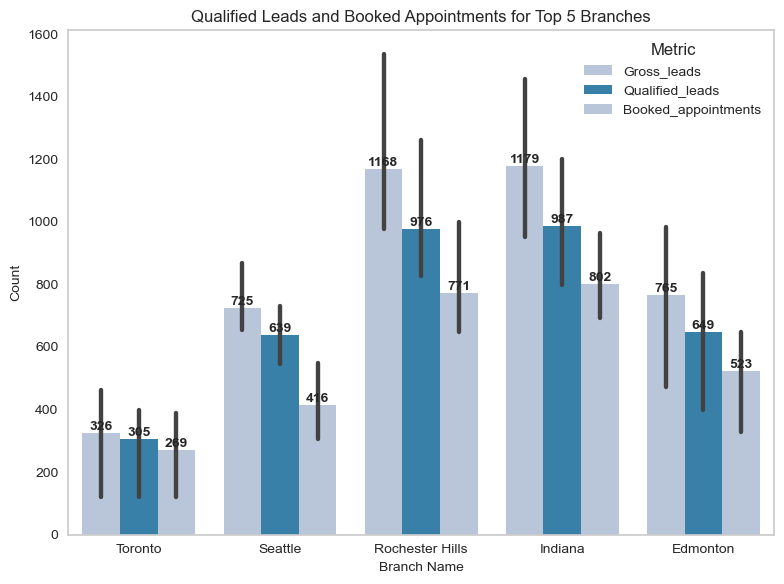

```python
melted_data = new_top_branches.melt(id_vars='BranchName', value_vars=['Gross_leads','Qualified_leads', 'Booked_appointments'],
                                 var_name='Metric', value_name='Count')
plt.figure(figsize=(8, 6))
pubu_colors = sns.color_palette("PuBu", n_colors=2)
sns.barplot(data=melted_data, x='BranchName', y='Count', hue='Metric', palette=pubu_colors)
plt.title('Qualified Leads and Booked Appointments for Top 5 Branches', fontsize=12)
plt.xlabel('Branch Name', fontsize=10)
plt.ylabel('Count', fontsize=10)
plt.xticks(fontsize=10)
plt.yticks(fontsize=10)
for container in plt.gca().containers:
    plt.gca().bar_label(container, fmt='%.0f', fontsize=10, weight='bold')
plt.grid(False)
plt.tight_layout()
plt.show()
```

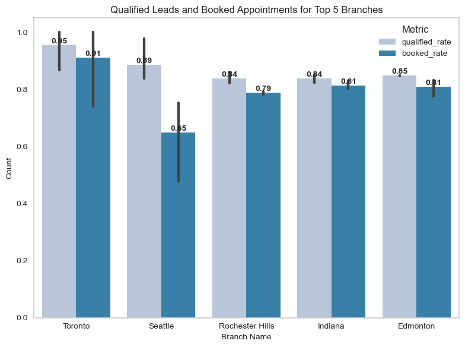

```python
melted_data = new_top_branches.melt(id_vars='BranchName', value_vars=['qualified_rate', 'booked_rate'],
                                 var_name='Metric', value_name='Count')
plt.figure(figsize=(8, 6))
pubu_colors = sns.color_palette("PuBu", n_colors=2)
sns.barplot(data=melted_data, x='BranchName', y='Count', hue='Metric', palette=pubu_colors)
plt.title('Qualified Leads and Booked Appointments for Top 5 Branches', fontsize=12)
plt.xlabel('Branch Name', fontsize=10)
plt.ylabel('Count', fontsize=10)
plt.xticks(fontsize=10)
plt.yticks(fontsize=10)
for container in plt.gca().containers:
    plt.gca().bar_label(container, fmt='%.02f', fontsize=10, weight='bold')
plt.grid(False)
plt.tight_layout()
plt.show()
```

The **heatmap** below shows how the variables correlate with each other and is ideal for identifying patterns and relationships between variables. It helps in visualizing which variables are strongly or weakly correlated, facilitating better understanding of their interdependencies. This tool is particularly useful for feature selection, multicollinearity assessment, and uncovering insights that may inform further analysis or model development. For instance, **IsSold** shows a strong positive correlation with **soldSubtotal**. Further analysis can be conducted for each market to identify which ones exhibit the strongest positive correlations and determine the specific variables involved.

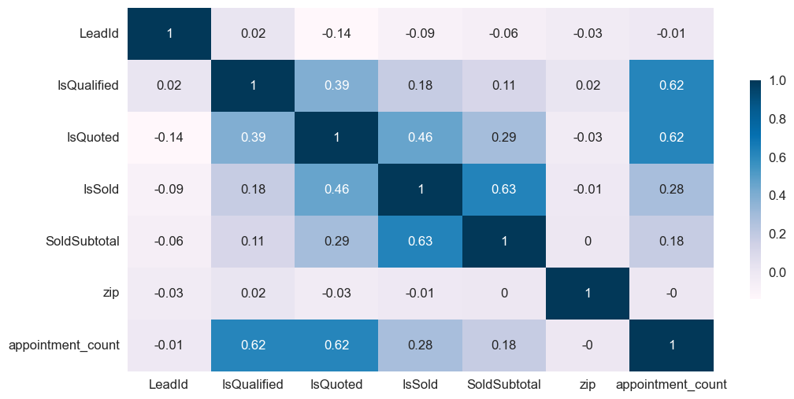

```python
plt.figure(figsize=(12,6))
heatmap=sns.heatmap(df.corr(numeric_only=True).round(2), cmap='PuBu', annot=True, annot_kws={"size": 12},
                    cbar_kws={"shrink":0.6})
heatmap.set_xticklabels(heatmap.get_xticklabels(), fontsize=12)
heatmap.set_yticklabels(heatmap.get_yticklabels(), fontsize=12)
cbar = heatmap.collections[0].colorbar
cbar.ax.tick_params(labelsize=12)
plt.show()
```